# Homework for MD Chapter 7

Here, we are going to practice and reinforce some of the ideas that we encountered in chapter 5. Sampling is crucial for understanding any type of data analysis. When you are presented with brand new set of data, it is always useful to think: what groups or populations am I capturing in these data? To what groups or populations can I extrapolate insights I draw from these data? Do I have enough data? To answer these questions, it is essential to grasp sampling; to think about how features of a population might (or might not) make their way to our spreadsheets.

Say we are interested in finding out the proportion of science Nobel prizes that have been awarded to people born in the US. We could easily Google this, the information is available. But imagine that for some reason we are only able to access portions of the data - i.e. samples. How would we go about finding this proportion and how confident would we be in our findings.

Let’s begin by loading in a data frame containing all Nobel prize winners.

```r
library(tidyverse)
library(here)
library(moderndive)
theme_set(theme_minimal())

nobel_winners <- read_csv("https://raw.githubusercontent.com/vaiseys/dav-course/main/Data/nobel_winners.csv")
```

Given that we are only interested in scientific Nobel prizes, let’s get rid of the Nobel Peace prize. We will also create a column that indicates whether the recipient was born in the US.

```r
nobel_winners_flt <- nobel_winners %>%
  filter(category != "Peace") %>%
  mutate(is_us = if_else(birth_country == "United States of America", 1, 0))
```

Now, what is the *true* proportion of US-born Nobel prize winners?

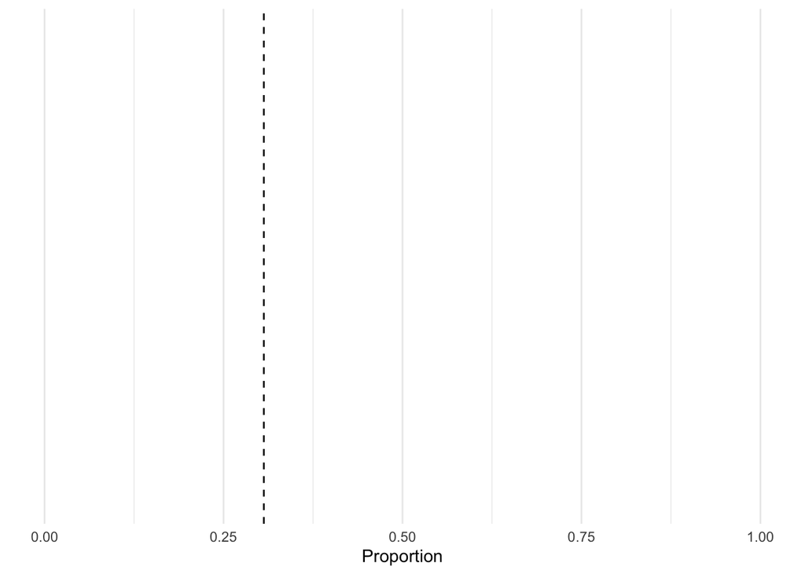

[figure not shown]

```r
true_prop <- nobel_winners_flt %>%
  group_by(is_us) %>%
  summarise(prop = n()/nrow(nobel_winners_flt))

ggplot() +
  coord_cartesian(xlim = c(0,1), ylim = c(0,1)) +
  geom_vline(xintercept = true_prop[2,2][[1]], linetype = "dashed")  +
  labs(x = "Proportion")
```

Now, let’s say our friend gives us a random sample of 25 Nobel winners and we calculate our proportion. How far off would we be?

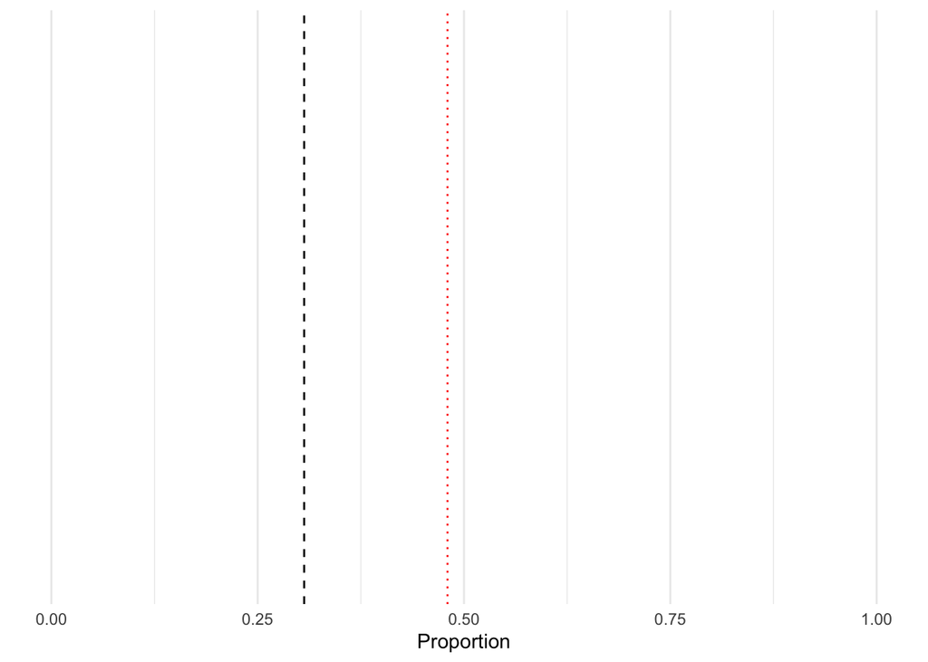

[figure not shown]

```r
set.seed(33)
# Random sample
our_sample <- sample_n(nobel_winners_flt,
                       size = 25,
                       replace = F)

sample_prop <- our_sample %>%
  group_by(is_us) %>%
  summarise(prop = n()/nrow(our_sample))

# How does our proportion look like?
ggplot() +
  coord_cartesian(xlim = c(0,1), ylim = c(0,1)) +
  geom_vline(xintercept = true_prop[2,2][[1]], linetype = "dashed")  +
  geom_vline(xintercept = sample_prop[2,2][[1]], linetype = "dotted", col = "red") +
  labs(x = "Proportion")
```

We are way above, almost at 50%!

## Question 1

Let’s explore some of the vocabulary provided in the chapter.

- In this scenario, what is the population? *All the Nobel Prize winners excluding Peace Prize winners
- What is the sampling frame? *25 of the Nobel Prize Winners excluding Peace Prize winners
- What does the black line represent? (hint: the word population is in the name). *The true proportion of US born winners
- What does the red line represent? *The proportion of US born winners from the sample

## Question 2

Okay, you probably know what we are doing next. We are going to take repeated samples of differing sizes and explore what the results look like, much like we did in the chapter. This will reinforce the ideas of sampling variability and sample size, which are key.

We will use the `rep_sample_n()` function from the **moderndive** package. (This is actually a copy of a function from the **infer** package, so it’s the sort of function you could continue to use in the future.)

Using this function, take 50 samples of 25 winners each. Plot your results. Be sure to add the mean proportion of your samples and the true proportion we calculated above. HINT: `summarize()` is going to be useful here.

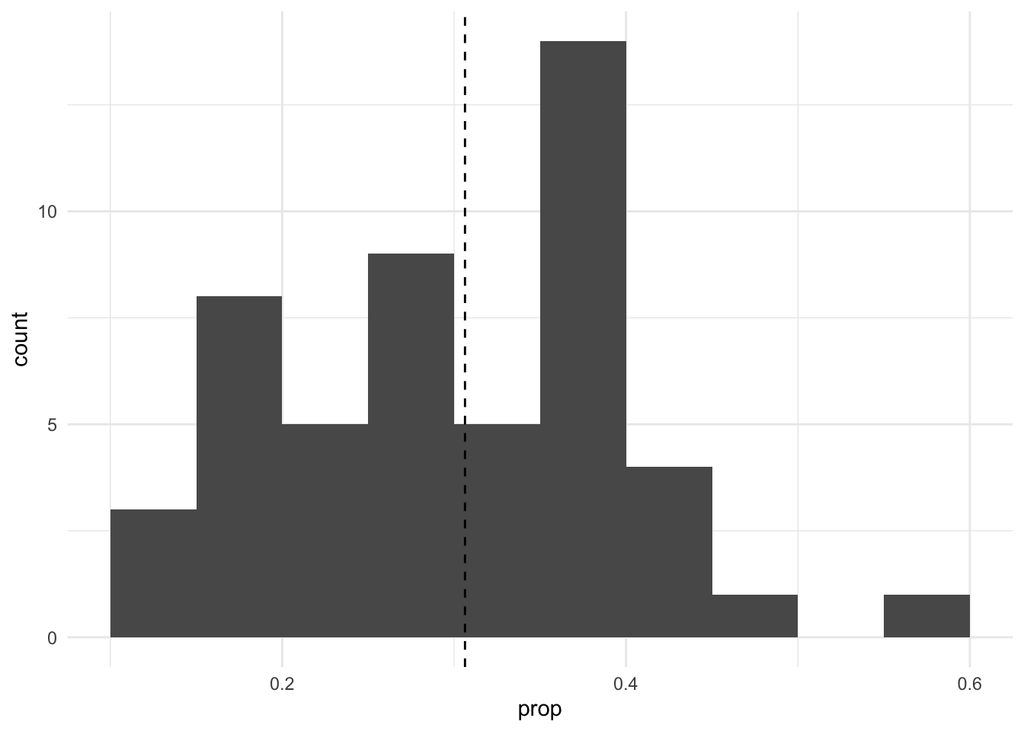

```r
fifty_samples <- rep_sample_n(nobel_winners_flt, 25, replace = FALSE, 50)

fifty_data <- fifty_samples %>%
  group_by(replicate) %>%
  summarize(prop = mean(is_us))

fifty_average <- fifty_data %>%
    summarise(avg_prop = mean(prop))

fifty_data |>
  ggplot(aes(x = prop)) +
  geom_histogram(data = fifty_data, boundary = 1, binwidth = .05) +
  geom_vline(xintercept = true_prop[2,2][[1]], linetype = "dashed")
```

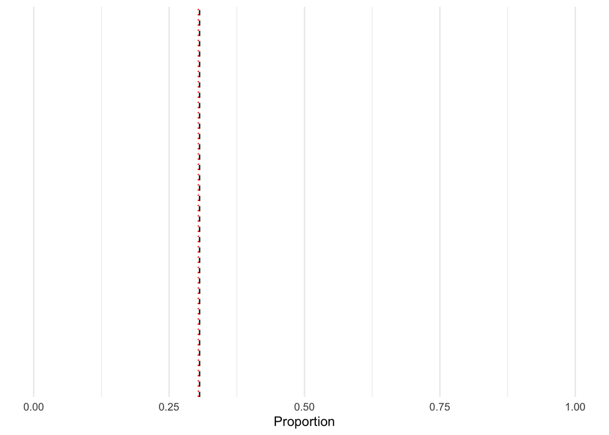

```r
ggplot() +
  coord_cartesian(xlim = c(0,1), ylim = c(0,1)) +
  geom_vline(xintercept = true_prop[2,2][[1]], linetype = "dashed")  +
  geom_vline(xintercept = fifty_average$avg_prop, linetype = "dotted", col = "red") +
  labs(x = "Proportion")
```

## Question 3

Now, use this function to take 50 samples of 100 winners each. Plot your results in the same way that you did above.

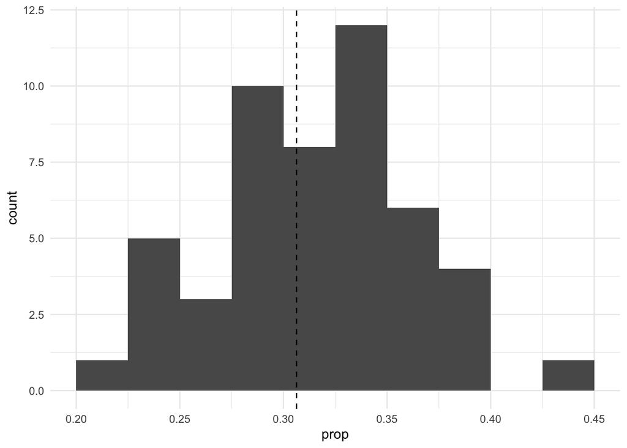

```r
fifty_samples_2 <- rep_sample_n(nobel_winners_flt, 100, replace = FALSE, 50)

fifty_data_2 <- fifty_samples_2 %>%
  group_by(replicate) %>%
  summarize(prop = mean(is_us))

fifty_average_2 <- fifty_data_2 %>%
    summarise(avg_prop = mean(prop))

fifty_data_2 |>
  ggplot(aes(x = prop)) +
  geom_histogram(data = fifty_data_2, boundary = 1, binwidth = .025) +
  geom_vline(xintercept = true_prop[2,2][[1]], linetype = "dashed")
```

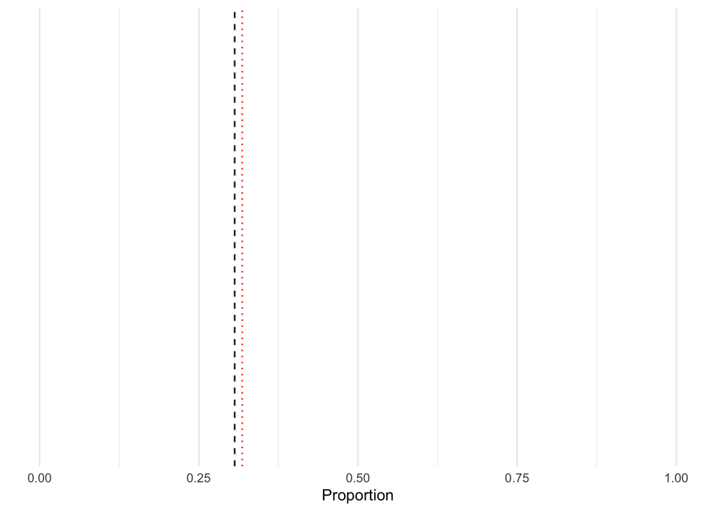

```r
ggplot() +
  coord_cartesian(xlim = c(0,1), ylim = c(0,1)) +
  geom_vline(xintercept = true_prop[2,2][[1]], linetype = "dashed")  +
  geom_vline(xintercept = fifty_average_2$avg_prop, linetype = "dotted", col = "red") +
  labs(x = "Proportion")
```

Which one of the two distributions varies more. Can you explain why? *The 25 sample data should vary more than the 100 sample data because the more reps taken, the average of those reps should approach the true proportion.

## Question 4

Calculate the standard deviation of your samples collected using a size of 25 and a size of 100. Do these results support your argument above? What does this imply about sample size? What happens to the variability in our estimates as the sample size increases

```r
s_25_sd <- sd(fifty_data$prop)
s_100_sd <- sd(fifty_data_2$prop)

s_25_sd
```

```
## [1] 0.1031741
```

```r
s_100_sd
```

```
## [1] 0.04766764
```

*Yes, the standard deviation of the 25 repetition data is higher than that of the 100 repetition data implying the samples deviate greater from the average of the samples. This leads to the idea that sample size has a significant impact on data quality and that small samples sizes can give a misleading and inconsistent outcome(standard deviation). Variability in our estimates decreases as sample size increases.

## Question 5

Now, repeat the same steps above to find the proportion of women who have been awarded the Nobel prize. Draw samples of 100 scientists at a time and plot your distribution of proportions.

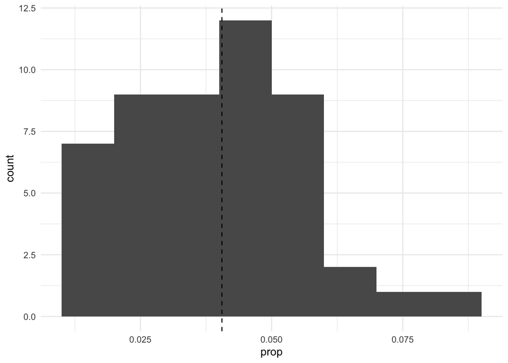

```r
#Get data and organize
nobel_winners_sex <- nobel_winners %>%
  filter(category != "Peace") %>%
  mutate(is_female = if_else(gender == "Female", 1, 0))

#Get samples
w_samples <- rep_sample_n(nobel_winners_sex, 100, replace = FALSE, 50)

#Assembles samples
w_data <- w_samples %>%
  group_by(replicate) %>%
  summarize(prop = mean(is_female))

#Find true proportion
w_true_prop <- nobel_winners_sex %>%
  group_by(is_female) %>%
  summarize(prop = n()/nrow(nobel_winners_sex))

#Find proportions of the samples
w_sample_prop <- w_samples %>%
  group_by(is_female) %>%
  summarize(prop = n()/nrow(w_samples))

#Find the average of the samples of the proportions
w_average <- w_data %>%
    summarise(avg_prop = mean(prop))

#Make histogram
w_data |>
  ggplot(aes(x = prop)) +
  geom_histogram(data = w_data, boundary = 1, binwidth = .01) +
  geom_vline(xintercept = w_true_prop[2,2][[1]], linetype = "dashed")
```

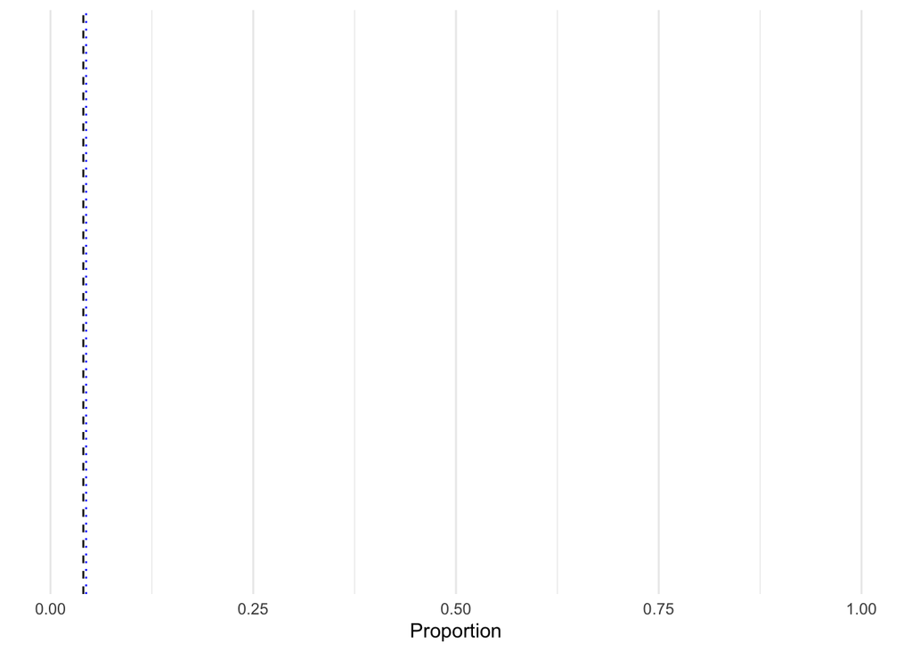

```r
#Make vline
ggplot() +
  coord_cartesian(xlim = c(0,1), ylim = c(0,1)) +
  geom_vline(xintercept = w_true_prop[2,2][[1]], linetype = "dashed")  +
  geom_vline(xintercept = w_sample_prop[2,2][[1]], linetype = "dotted", col = "blue") +
  labs(x = "Proportion")
```

## Question 6

The last question is a bit different. Please watch [this video](https://www.youtube.com/watch?v=jvoxEYmQHNM) referenced in the ModernDive book, then explain the **Central Limit Theorem** it in your own words. Be as concise as you can (i.e., use no more than 3-4 sentences) but convince me you really understand the basic idea.

*Sample size is inversely proportional to the variability between the sample distribution and the true distribution. This is fairly intuitive as sample size = (total population - 1) should be almost identical to sample size = total population and as more of the population is omitted the more potential for variation.